# Risk Factor Analysis

## Outcome Variable

**Outcome Variable:** stunted

## Predictor Variables

**Intervention Variable:** meducyrs

**Adjustment Set:**

unadjusted

## Stratifying Variables

The analysis was stratified on these variable(s):

- agecat
- studyid
- country

## Data Summary

| agecat | studyid | country | meducyrs | stunted | n_cell | n |
| --- | --- | --- | --- | --- | --- | --- |
| Birth | ki0047075b-MAL-ED | BANGLADESH | Q4 | 0 | 55 | 207 |
| Birth | ki0047075b-MAL-ED | BANGLADESH | Q4 | 1 | 4 | 207 |
| Birth | ki0047075b-MAL-ED | BANGLADESH | Q1 | 0 | 28 | 207 |
| Birth | ki0047075b-MAL-ED | BANGLADESH | Q1 | 1 | 12 | 207 |
| Birth | ki0047075b-MAL-ED | BANGLADESH | Q2 | 0 | 23 | 207 |
| Birth | ki0047075b-MAL-ED | BANGLADESH | Q2 | 1 | 5 | 207 |
| Birth | ki0047075b-MAL-ED | BANGLADESH | Q3 | 0 | 65 | 207 |
| Birth | ki0047075b-MAL-ED | BANGLADESH | Q3 | 1 | 15 | 207 |
| 6 months | ki0047075b-MAL-ED | BANGLADESH | Q4 | 0 | 53 | 196 |
| 6 months | ki0047075b-MAL-ED | BANGLADESH | Q4 | 1 | 4 | 196 |
| 6 months | ki0047075b-MAL-ED | BANGLADESH | Q1 | 0 | 27 | 196 |
| 6 months | ki0047075b-MAL-ED | BANGLADESH | Q1 | 1 | 12 | 196 |
| 6 months | ki0047075b-MAL-ED | BANGLADESH | Q2 | 0 | 23 | 196 |
| 6 months | ki0047075b-MAL-ED | BANGLADESH | Q2 | 1 | 2 | 196 |
| 6 months | ki0047075b-MAL-ED | BANGLADESH | Q3 | 0 | 58 | 196 |
| 6 months | ki0047075b-MAL-ED | BANGLADESH | Q3 | 1 | 17 | 196 |
| 24 months | ki0047075b-MAL-ED | BANGLADESH | Q4 | 0 | 29 | 171 |
| 24 months | ki0047075b-MAL-ED | BANGLADESH | Q4 | 1 | 22 | 171 |
| 24 months | ki0047075b-MAL-ED | BANGLADESH | Q1 | 0 | 16 | 171 |
| 24 months | ki0047075b-MAL-ED | BANGLADESH | Q1 | 1 | 20 | 171 |
| 24 months | ki0047075b-MAL-ED | BANGLADESH | Q2 | 0 | 16 | 171 |
| 24 months | ki0047075b-MAL-ED | BANGLADESH | Q2 | 1 | 7 | 171 |
| 24 months | ki0047075b-MAL-ED | BANGLADESH | Q3 | 0 | 34 | 171 |
| 24 months | ki0047075b-MAL-ED | BANGLADESH | Q3 | 1 | 27 | 171 |
| Birth | ki0047075b-MAL-ED | BRAZIL | Q4 | 0 | 58 | 190 |
| Birth | ki0047075b-MAL-ED | BRAZIL | Q4 | 1 | 7 | 190 |
| Birth | ki0047075b-MAL-ED | BRAZIL | Q1 | 0 | 37 | 190 |
| Birth | ki0047075b-MAL-ED | BRAZIL | Q1 | 1 | 3 | 190 |
| Birth | ki0047075b-MAL-ED | BRAZIL | Q2 | 0 | 29 | 190 |
| Birth | ki0047075b-MAL-ED | BRAZIL | Q2 | 1 | 7 | 190 |

[output cut: 498 more lines]

The following strata were considered:

- agecat: 24 months, studyid: ki0047075b-MAL-ED, country: BANGLADESH
- agecat: 24 months, studyid: ki0047075b-MAL-ED, country: BRAZIL
- agecat: 24 months, studyid: ki0047075b-MAL-ED, country: INDIA
- agecat: 24 months, studyid: ki0047075b-MAL-ED, country: NEPAL
- agecat: 24 months, studyid: ki0047075b-MAL-ED, country: PERU
- agecat: 24 months, studyid: ki0047075b-MAL-ED, country: SOUTH AFRICA
- agecat: 24 months, studyid: ki0047075b-MAL-ED, country: TANZANIA, UNITED REPUBLIC OF
- agecat: 24 months, studyid: ki1000108-CMC-V-BCS-2002, country: INDIA
- agecat: 24 months, studyid: ki1000108-IRC, country: INDIA
- agecat: 24 months, studyid: ki1017093-NIH-Birth, country: BANGLADESH
- agecat: 24 months, studyid: ki1017093b-PROVIDE, country: BANGLADESH
- agecat: 24 months, studyid: ki1017093c-NIH-Crypto, country: BANGLADESH
- agecat: 24 months, studyid: ki1066203-TanzaniaChild2, country: TANZANIA, UNITED REPUBLIC OF
- agecat: 24 months, studyid: ki1113344-GMS-Nepal, country: NEPAL
- agecat: 24 months, studyid: ki1119695-PROBIT, country: BELARUS
- agecat: 24 months, studyid: ki1126311-ZVITAMBO, country: ZIMBABWE
- agecat: 24 months, studyid: ki1135781-COHORTS, country: GUATEMALA
- agecat: 24 months, studyid: ki1135781-COHORTS, country: INDIA
- agecat: 24 months, studyid: ki1135781-COHORTS, country: PHILIPPINES
- agecat: 24 months, studyid: ki1148112-LCNI-5, country: MALAWI
- agecat: 24 months, studyid: kiGH5241-JiVitA-3, country: BANGLADESH
- agecat: 24 months, studyid: kiGH5241-JiVitA-4, country: BANGLADESH
- agecat: 6 months, studyid: ki0047075b-MAL-ED, country: BANGLADESH
- agecat: 6 months, studyid: ki0047075b-MAL-ED, country: BRAZIL
- agecat: 6 months, studyid: ki0047075b-MAL-ED, country: INDIA
- agecat: 6 months, studyid: ki0047075b-MAL-ED, country: NEPAL
- agecat: 6 months, studyid: ki0047075b-MAL-ED, country: PERU
- agecat: 6 months, studyid: ki0047075b-MAL-ED, country: SOUTH AFRICA
- agecat: 6 months, studyid: ki0047075b-MAL-ED, country: TANZANIA, UNITED REPUBLIC OF
- agecat: 6 months, studyid: ki1000108-CMC-V-BCS-2002, country: INDIA
- agecat: 6 months, studyid: ki1000108-IRC, country: INDIA
- agecat: 6 months, studyid: ki1000109-EE, country: PAKISTAN
- agecat: 6 months, studyid: ki1000304b-SAS-CompFeed, country: INDIA
- agecat: 6 months, studyid: ki1000304b-SAS-FoodSuppl, country: INDIA
- agecat: 6 months, studyid: ki1017093-NIH-Birth, country: BANGLADESH
- agecat: 6 months, studyid: ki1017093b-PROVIDE, country: BANGLADESH
- agecat: 6 months, studyid: ki1017093c-NIH-Crypto, country: BANGLADESH
- agecat: 6 months, studyid: ki1066203-TanzaniaChild2, country: TANZANIA, UNITED REPUBLIC OF
- agecat: 6 months, studyid: ki1112895-Guatemala BSC, country: GUATEMALA
- agecat: 6 months, studyid: ki1113344-GMS-Nepal, country: NEPAL
- agecat: 6 months, studyid: ki1119695-PROBIT, country: BELARUS
- agecat: 6 months, studyid: ki1126311-ZVITAMBO, country: ZIMBABWE
- agecat: 6 months, studyid: ki1135781-COHORTS, country: GUATEMALA
- agecat: 6 months, studyid: ki1135781-COHORTS, country: INDIA
- agecat: 6 months, studyid: ki1135781-COHORTS, country: PHILIPPINES
- agecat: 6 months, studyid: ki1148112-LCNI-5, country: MALAWI
- agecat: 6 months, studyid: kiGH5241-JiVitA-3, country: BANGLADESH
- agecat: 6 months, studyid: kiGH5241-JiVitA-4, country: BANGLADESH
- agecat: Birth, studyid: ki0047075b-MAL-ED, country: BANGLADESH
- agecat: Birth, studyid: ki0047075b-MAL-ED, country: BRAZIL
- agecat: Birth, studyid: ki0047075b-MAL-ED, country: INDIA
- agecat: Birth, studyid: ki0047075b-MAL-ED, country: NEPAL
- agecat: Birth, studyid: ki0047075b-MAL-ED, country: PERU
- agecat: Birth, studyid: ki0047075b-MAL-ED, country: SOUTH AFRICA
- agecat: Birth, studyid: ki0047075b-MAL-ED, country: TANZANIA, UNITED REPUBLIC OF
- agecat: Birth, studyid: ki1000108-CMC-V-BCS-2002, country: INDIA
- agecat: Birth, studyid: ki1000108-IRC, country: INDIA
- agecat: Birth, studyid: ki1000109-EE, country: PAKISTAN
- agecat: Birth, studyid: ki1000304b-SAS-CompFeed, country: INDIA
- agecat: Birth, studyid: ki1017093-NIH-Birth, country: BANGLADESH
- agecat: Birth, studyid: ki1017093c-NIH-Crypto, country: BANGLADESH
- agecat: Birth, studyid: ki1119695-PROBIT, country: BELARUS
- agecat: Birth, studyid: ki1126311-ZVITAMBO, country: ZIMBABWE
- agecat: Birth, studyid: ki1135781-COHORTS, country: GUATEMALA
- agecat: Birth, studyid: ki1135781-COHORTS, country: INDIA
- agecat: Birth, studyid: ki1135781-COHORTS, country: PHILIPPINES
- agecat: Birth, studyid: kiGH5241-JiVitA-3, country: BANGLADESH
- agecat: Birth, studyid: kiGH5241-JiVitA-4, country: BANGLADESH

### Dropped Strata

Some strata were dropped due to rare outcomes:

- agecat: Birth, studyid: ki0047075b-MAL-ED, country: BANGLADESH
- agecat: 6 months, studyid: ki0047075b-MAL-ED, country: BANGLADESH
- agecat: Birth, studyid: ki0047075b-MAL-ED, country: BRAZIL
- agecat: 6 months, studyid: ki0047075b-MAL-ED, country: BRAZIL
- agecat: 24 months, studyid: ki0047075b-MAL-ED, country: BRAZIL
- agecat: Birth, studyid: ki0047075b-MAL-ED, country: INDIA
- agecat: Birth, studyid: ki0047075b-MAL-ED, country: NEPAL
- agecat: 6 months, studyid: ki0047075b-MAL-ED, country: NEPAL
- agecat: 24 months, studyid: ki0047075b-MAL-ED, country: NEPAL
- agecat: Birth, studyid: ki0047075b-MAL-ED, country: SOUTH AFRICA
- agecat: Birth, studyid: ki0047075b-MAL-ED, country: TANZANIA, UNITED REPUBLIC OF
- agecat: 6 months, studyid: ki0047075b-MAL-ED, country: TANZANIA, UNITED REPUBLIC OF
- agecat: 24 months, studyid: ki0047075b-MAL-ED, country: TANZANIA, UNITED REPUBLIC OF
- agecat: Birth, studyid: ki1000108-CMC-V-BCS-2002, country: INDIA
- agecat: 6 months, studyid: ki1000108-IRC, country: INDIA
- agecat: 24 months, studyid: ki1000108-IRC, country: INDIA
- agecat: Birth, studyid: ki1000108-IRC, country: INDIA
- agecat: 6 months, studyid: ki1000109-EE, country: PAKISTAN
- agecat: Birth, studyid: ki1000109-EE, country: PAKISTAN
- agecat: Birth, studyid: ki1000304b-SAS-CompFeed, country: INDIA
- agecat: 6 months, studyid: ki1000304b-SAS-FoodSuppl, country: INDIA
- agecat: Birth, studyid: ki1017093-NIH-Birth, country: BANGLADESH
- agecat: 6 months, studyid: ki1017093b-PROVIDE, country: BANGLADESH
- agecat: 24 months, studyid: ki1017093b-PROVIDE, country: BANGLADESH
- agecat: Birth, studyid: ki1017093c-NIH-Crypto, country: BANGLADESH
- agecat: 6 months, studyid: ki1066203-TanzaniaChild2, country: TANZANIA, UNITED REPUBLIC OF
- agecat: 24 months, studyid: ki1066203-TanzaniaChild2, country: TANZANIA, UNITED REPUBLIC OF
- agecat: Birth, studyid: ki1119695-PROBIT, country: BELARUS
- agecat: 24 months, studyid: ki1126311-ZVITAMBO, country: ZIMBABWE
- agecat: 24 months, studyid: ki1135781-COHORTS, country: GUATEMALA
- agecat: 6 months, studyid: ki1135781-COHORTS, country: GUATEMALA
- agecat: Birth, studyid: ki1135781-COHORTS, country: GUATEMALA
- agecat: 6 months, studyid: ki1148112-LCNI-5, country: MALAWI
- agecat: 24 months, studyid: ki1148112-LCNI-5, country: MALAWI
- agecat: Birth, studyid: kiGH5241-JiVitA-4, country: BANGLADESH

## Methods Detail

We’re interested in the causal parameters $E[Y_a]$ for all values of $a \in \mathcal{A}$. These parameters represent the mean outcome if, possibly contrary to fact, we intervened to set all units to have $A=a$. Under the randomization and positivity assumptions, these are identified by the statistical parameters $\psi_a=E_W[E_{Y|A,W}(Y|A=a,W)]$. In addition, we’re interested in the mean of $Y$, $E[Y]$ under no intervention (the observed mean). We will estimate these parameters by using SuperLearner to fit the relevant likelihood factors – $E_{Y|A,W}(Y|A=a,W)$ and $p(A=a|W)$, and then updating our likelihood fit using a joint TMLE.

For unadjusted analyses ($W=\{\}$), initial likelihoods were estimated using Lrnr_glm to estimate the simple $E(Y|A)$ and Lrnr_mean to estimate $p(A)$. For adjusted analyses, a small library containing Lrnr_glmnet, Lrnr_xgboost, and Lrnr_mean was used.

Having estimated these parameters, we will then use the delta method to estimate relative risks and attributable risks relative to a prespecified baseline level of $A$.

# Results Detail

## Results Plots

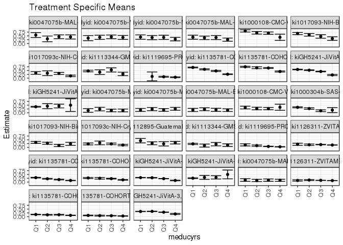

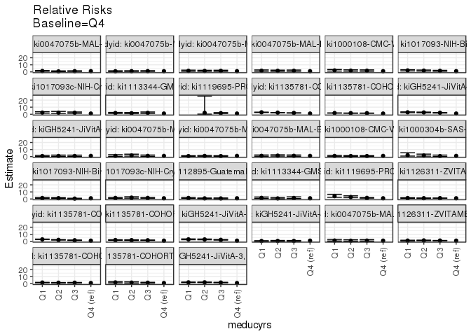

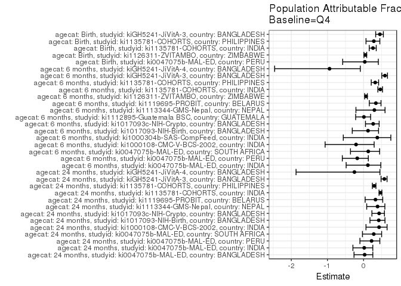

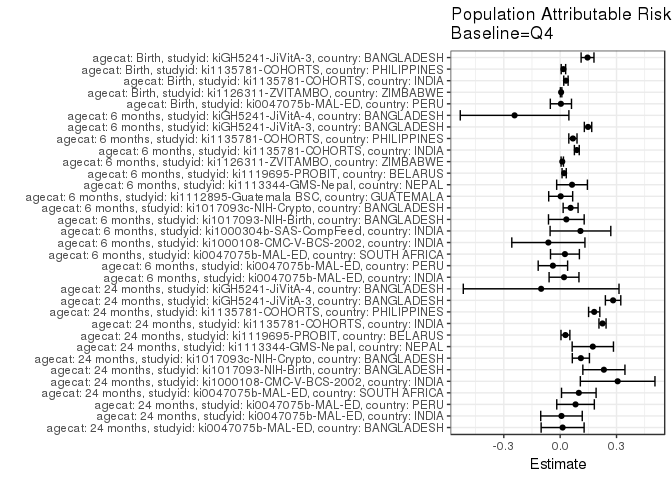

## Results Table

### Parameter: TSM

| agecat | studyid | country | intervention_level | baseline_level | estimate | ci_lower | ci_upper |
| --- | --- | --- | --- | --- | --- | --- | --- |
| Birth | ki0047075b-MAL-ED | PERU | Q4 | NA | 0.1149425 | 0.0478035 | 0.1820816 |
| Birth | ki0047075b-MAL-ED | PERU | Q1 | NA | 0.1333333 | 0.0471688 | 0.2194979 |
| Birth | ki0047075b-MAL-ED | PERU | Q2 | NA | 0.1044776 | 0.0311072 | 0.1778481 |
| Birth | ki0047075b-MAL-ED | PERU | Q3 | NA | 0.1250000 | 0.0484753 | 0.2015247 |
| Birth | ki1126311-ZVITAMBO | ZIMBABWE | Q4 | NA | 0.0986547 | 0.0923874 | 0.1049221 |
| Birth | ki1126311-ZVITAMBO | ZIMBABWE | Q1 | NA | 0.1057692 | 0.0639730 | 0.1475654 |
| Birth | ki1126311-ZVITAMBO | ZIMBABWE | Q2 | NA | 0.1309524 | 0.0986884 | 0.1632163 |
| Birth | ki1126311-ZVITAMBO | ZIMBABWE | Q3 | NA | 0.1108138 | 0.1016268 | 0.1200009 |
| Birth | ki1135781-COHORTS | INDIA | Q4 | NA | 0.0875995 | 0.0743828 | 0.1008163 |
| Birth | ki1135781-COHORTS | INDIA | Q1 | NA | 0.1429385 | 0.1265663 | 0.1593107 |
| Birth | ki1135781-COHORTS | INDIA | Q2 | NA | 0.1228669 | 0.1011626 | 0.1445712 |
| Birth | ki1135781-COHORTS | INDIA | Q3 | NA | 0.1263670 | 0.1036646 | 0.1490693 |
| Birth | ki1135781-COHORTS | PHILIPPINES | Q4 | NA | 0.0439443 | 0.0307899 | 0.0570987 |
| Birth | ki1135781-COHORTS | PHILIPPINES | Q1 | NA | 0.0815047 | 0.0602704 | 0.1027390 |
| Birth | ki1135781-COHORTS | PHILIPPINES | Q2 | NA | 0.0687023 | 0.0380687 | 0.0993359 |
| Birth | ki1135781-COHORTS | PHILIPPINES | Q3 | NA | 0.0624486 | 0.0488520 | 0.0760453 |
| Birth | kiGH5241-JiVitA-3 | BANGLADESH | Q4 | NA | 0.1775568 | 0.1429388 | 0.2121748 |
| Birth | kiGH5241-JiVitA-3 | BANGLADESH | Q1 | NA | 0.3432949 | 0.3319585 | 0.3546313 |
| Birth | kiGH5241-JiVitA-3 | BANGLADESH | Q2 | NA | 0.3499892 | 0.3351389 | 0.3648395 |
| Birth | kiGH5241-JiVitA-3 | BANGLADESH | Q3 | NA | 0.2951438 | 0.2825656 | 0.3077220 |
| 6 months | ki0047075b-MAL-ED | INDIA | Q4 | NA | 0.1525424 | 0.0605773 | 0.2445074 |
| 6 months | ki0047075b-MAL-ED | INDIA | Q1 | NA | 0.1515152 | 0.0288877 | 0.2741426 |
| 6 months | ki0047075b-MAL-ED | INDIA | Q2 | NA | 0.2400000 | 0.1213352 | 0.3586648 |
| 6 months | ki0047075b-MAL-ED | INDIA | Q3 | NA | 0.1515152 | 0.0648045 | 0.2382259 |
| 6 months | ki0047075b-MAL-ED | PERU | Q4 | NA | 0.2592593 | 0.1636487 | 0.3548698 |
| 6 months | ki0047075b-MAL-ED | PERU | Q1 | NA | 0.1864407 | 0.0868802 | 0.2860011 |
| 6 months | ki0047075b-MAL-ED | PERU | Q2 | NA | 0.2419355 | 0.1351395 | 0.3487315 |
| 6 months | ki0047075b-MAL-ED | PERU | Q3 | NA | 0.1857143 | 0.0944481 | 0.2769805 |
| 6 months | ki0047075b-MAL-ED | SOUTH AFRICA | Q4 | NA | 0.1714286 | 0.0829655 | 0.2598917 |
| 6 months | ki0047075b-MAL-ED | SOUTH AFRICA | Q1 | NA | 0.1851852 | 0.0813749 | 0.2889955 |

[output cut: 101 more lines]

### Parameter: E(Y)

| agecat | studyid | country | intervention_level | baseline_level | estimate | ci_lower | ci_upper |
| --- | --- | --- | --- | --- | --- | --- | --- |
| Birth | ki0047075b-MAL-ED | PERU | NA | NA | 0.1188811 | 0.0813061 | 0.1564562 |
| Birth | ki1126311-ZVITAMBO | ZIMBABWE | NA | NA | 0.1036930 | 0.0986082 | 0.1087777 |
| Birth | ki1135781-COHORTS | INDIA | NA | NA | 0.1182899 | 0.1095248 | 0.1270550 |
| Birth | ki1135781-COHORTS | PHILIPPINES | NA | NA | 0.0613115 | 0.0527962 | 0.0698268 |
| Birth | kiGH5241-JiVitA-3 | BANGLADESH | NA | NA | 0.3232756 | 0.3156176 | 0.3309337 |
| 6 months | ki0047075b-MAL-ED | INDIA | NA | NA | 0.1730769 | 0.1215404 | 0.2246134 |
| 6 months | ki0047075b-MAL-ED | PERU | NA | NA | 0.2205882 | 0.1712211 | 0.2699554 |
| 6 months | ki0047075b-MAL-ED | SOUTH AFRICA | NA | NA | 0.1968504 | 0.1478551 | 0.2458457 |
| 6 months | ki1000108-CMC-V-BCS-2002 | INDIA | NA | NA | 0.3008130 | 0.2539566 | 0.3476694 |
| 6 months | ki1000304b-SAS-CompFeed | INDIA | NA | NA | 0.2844311 | 0.2666491 | 0.3022132 |
| 6 months | ki1017093-NIH-Birth | BANGLADESH | NA | NA | 0.2681564 | 0.2306532 | 0.3056597 |
| 6 months | ki1017093c-NIH-Crypto | BANGLADESH | NA | NA | 0.2097902 | 0.1799252 | 0.2396552 |
| 6 months | ki1112895-Guatemala BSC | GUATEMALA | NA | NA | 0.3104693 | 0.2558835 | 0.3650551 |
| 6 months | ki1113344-GMS-Nepal | NEPAL | NA | NA | 0.2125000 | 0.1785885 | 0.2464115 |
| 6 months | ki1119695-PROBIT | BELARUS | NA | NA | 0.0626864 | 0.0488489 | 0.0765239 |
| 6 months | ki1126311-ZVITAMBO | ZIMBABWE | NA | NA | 0.1665057 | 0.1584820 | 0.1745293 |
| 6 months | ki1135781-COHORTS | INDIA | NA | NA | 0.1915758 | 0.1810911 | 0.2020606 |
| 6 months | ki1135781-COHORTS | PHILIPPINES | NA | NA | 0.2112260 | 0.1958496 | 0.2266024 |
| 6 months | kiGH5241-JiVitA-3 | BANGLADESH | NA | NA | 0.2514589 | 0.2433251 | 0.2595926 |
| 6 months | kiGH5241-JiVitA-4 | BANGLADESH | NA | NA | 0.2573674 | 0.2348896 | 0.2798452 |
| 24 months | ki0047075b-MAL-ED | BANGLADESH | NA | NA | 0.4444444 | 0.3697487 | 0.5191402 |
| 24 months | ki0047075b-MAL-ED | INDIA | NA | NA | 0.4070352 | 0.3386053 | 0.4754651 |
| 24 months | ki0047075b-MAL-ED | PERU | NA | NA | 0.3700000 | 0.3029201 | 0.4370799 |
| 24 months | ki0047075b-MAL-ED | SOUTH AFRICA | NA | NA | 0.3529412 | 0.2921001 | 0.4137823 |
| 24 months | ki1000108-CMC-V-BCS-2002 | INDIA | NA | NA | 0.7150538 | 0.6691221 | 0.7609854 |
| 24 months | ki1017093-NIH-Birth | BANGLADESH | NA | NA | 0.5547786 | 0.5076945 | 0.6018626 |
| 24 months | ki1017093c-NIH-Crypto | BANGLADESH | NA | NA | 0.2568093 | 0.2190047 | 0.2946140 |
| 24 months | ki1113344-GMS-Nepal | NEPAL | NA | NA | 0.4495968 | 0.4057742 | 0.4934193 |
| 24 months | ki1119695-PROBIT | BELARUS | NA | NA | 0.0852540 | 0.0554439 | 0.1150642 |
| 24 months | ki1135781-COHORTS | INDIA | NA | NA | 0.4815520 | 0.4664409 | 0.4966632 |
| 24 months | ki1135781-COHORTS | PHILIPPINES | NA | NA | 0.6167689 | 0.5974942 | 0.6360437 |
| 24 months | kiGH5241-JiVitA-3 | BANGLADESH | NA | NA | 0.4907783 | 0.4776560 | 0.5039007 |
| 24 months | kiGH5241-JiVitA-4 | BANGLADESH | NA | NA | 0.3988036 | 0.3729992 | 0.4246080 |

### Parameter: RR

| agecat | studyid | country | intervention_level | baseline_level | estimate | ci_lower | ci_upper |
| --- | --- | --- | --- | --- | --- | --- | --- |
| Birth | ki0047075b-MAL-ED | PERU | Q4 | Q4 | 1.0000000 | 1.0000000 | 1.0000000 |
| Birth | ki0047075b-MAL-ED | PERU | Q1 | Q4 | 1.1600000 | 0.4854531 | 2.7718435 |
| Birth | ki0047075b-MAL-ED | PERU | Q2 | Q4 | 0.9089552 | 0.3646239 | 2.2658951 |
| Birth | ki0047075b-MAL-ED | PERU | Q3 | Q4 | 1.0875000 | 0.4666067 | 2.5345888 |
| Birth | ki1126311-ZVITAMBO | ZIMBABWE | Q4 | Q4 | 1.0000000 | 1.0000000 | 1.0000000 |
| Birth | ki1126311-ZVITAMBO | ZIMBABWE | Q1 | Q4 | 1.0721154 | 0.7184895 | 1.5997886 |
| Birth | ki1126311-ZVITAMBO | ZIMBABWE | Q2 | Q4 | 1.3273809 | 1.0291878 | 1.7119714 |
| Birth | ki1126311-ZVITAMBO | ZIMBABWE | Q3 | Q4 | 1.1232492 | 1.0118486 | 1.2469146 |
| Birth | ki1135781-COHORTS | INDIA | Q4 | Q4 | 1.0000000 | 1.0000000 | 1.0000000 |
| Birth | ki1135781-COHORTS | INDIA | Q1 | Q4 | 1.6317265 | 1.3501420 | 1.9720379 |
| Birth | ki1135781-COHORTS | INDIA | Q2 | Q4 | 1.4025974 | 1.1118380 | 1.7693940 |
| Birth | ki1135781-COHORTS | INDIA | Q3 | Q4 | 1.4425526 | 1.1408908 | 1.8239765 |
| Birth | ki1135781-COHORTS | PHILIPPINES | Q4 | Q4 | 1.0000000 | 1.0000000 | 1.0000000 |
| Birth | ki1135781-COHORTS | PHILIPPINES | Q1 | Q4 | 1.8547289 | 1.2471976 | 2.7581991 |
| Birth | ki1135781-COHORTS | PHILIPPINES | Q2 | Q4 | 1.5633960 | 0.9137570 | 2.6748980 |
| Birth | ki1135781-COHORTS | PHILIPPINES | Q3 | Q4 | 1.4210874 | 0.9814470 | 2.0576652 |
| Birth | kiGH5241-JiVitA-3 | BANGLADESH | Q4 | Q4 | 1.0000000 | 1.0000000 | 1.0000000 |
| Birth | kiGH5241-JiVitA-3 | BANGLADESH | Q1 | Q4 | 1.9334370 | 1.5871306 | 2.3553062 |
| Birth | kiGH5241-JiVitA-3 | BANGLADESH | Q2 | Q4 | 1.9711391 | 1.6145377 | 2.4065028 |
| Birth | kiGH5241-JiVitA-3 | BANGLADESH | Q3 | Q4 | 1.6622499 | 1.3613265 | 2.0296928 |
| 6 months | ki0047075b-MAL-ED | INDIA | Q4 | Q4 | 1.0000000 | 1.0000000 | 1.0000000 |
| 6 months | ki0047075b-MAL-ED | INDIA | Q1 | Q4 | 0.9932660 | 0.3620531 | 2.7249518 |
| 6 months | ki0047075b-MAL-ED | INDIA | Q2 | Q4 | 1.5733333 | 0.7214408 | 3.4311587 |
| 6 months | ki0047075b-MAL-ED | INDIA | Q3 | Q4 | 0.9932660 | 0.4325701 | 2.2807339 |
| 6 months | ki0047075b-MAL-ED | PERU | Q4 | Q4 | 1.0000000 | 1.0000000 | 1.0000000 |
| 6 months | ki0047075b-MAL-ED | PERU | Q1 | Q4 | 0.7191283 | 0.3758043 | 1.3761032 |
| 6 months | ki0047075b-MAL-ED | PERU | Q2 | Q4 | 0.9331797 | 0.5249994 | 1.6587150 |
| 6 months | ki0047075b-MAL-ED | PERU | Q3 | Q4 | 0.7163265 | 0.3875014 | 1.3241855 |
| 6 months | ki0047075b-MAL-ED | SOUTH AFRICA | Q4 | Q4 | 1.0000000 | 1.0000000 | 1.0000000 |
| 6 months | ki0047075b-MAL-ED | SOUTH AFRICA | Q1 | Q4 | 1.0802469 | 0.5042213 | 2.3143280 |

[output cut: 101 more lines]

### Parameter: PAR

| agecat | studyid | country | intervention_level | baseline_level | estimate | ci_lower | ci_upper |
| --- | --- | --- | --- | --- | --- | --- | --- |
| Birth | ki0047075b-MAL-ED | PERU | Q4 | NA | 0.0039386 | -0.0524273 | 0.0603045 |
| Birth | ki1126311-ZVITAMBO | ZIMBABWE | Q4 | NA | 0.0050383 | 0.0010809 | 0.0089956 |
| Birth | ki1135781-COHORTS | INDIA | Q4 | NA | 0.0306903 | 0.0191249 | 0.0422558 |
| Birth | ki1135781-COHORTS | PHILIPPINES | Q4 | NA | 0.0173672 | 0.0055484 | 0.0291860 |
| Birth | kiGH5241-JiVitA-3 | BANGLADESH | Q4 | NA | 0.1457188 | 0.1115059 | 0.1799317 |
| 6 months | ki0047075b-MAL-ED | INDIA | Q4 | NA | 0.0205346 | -0.0589358 | 0.1000049 |
| 6 months | ki0047075b-MAL-ED | PERU | Q4 | NA | -0.0386710 | -0.1169908 | 0.0396488 |
| 6 months | ki0047075b-MAL-ED | SOUTH AFRICA | Q4 | NA | 0.0254218 | -0.0514734 | 0.1023170 |
| 6 months | ki1000108-CMC-V-BCS-2002 | INDIA | Q4 | NA | -0.0628234 | -0.2574517 | 0.1318050 |
| 6 months | ki1000304b-SAS-CompFeed | INDIA | Q4 | NA | 0.1079605 | -0.0535355 | 0.2694566 |
| 6 months | ki1017093-NIH-Birth | BANGLADESH | Q4 | NA | 0.0328623 | -0.0620641 | 0.1277887 |
| 6 months | ki1017093c-NIH-Crypto | BANGLADESH | Q4 | NA | 0.0556235 | 0.0158885 | 0.0953586 |
| 6 months | ki1112895-Guatemala BSC | GUATEMALA | Q4 | NA | 0.0027770 | -0.0610137 | 0.0665677 |
| 6 months | ki1113344-GMS-Nepal | NEPAL | Q4 | NA | 0.0632463 | -0.0185956 | 0.1450881 |
| 6 months | ki1119695-PROBIT | BELARUS | Q4 | NA | 0.0212863 | 0.0100963 | 0.0324763 |
| 6 months | ki1126311-ZVITAMBO | ZIMBABWE | Q4 | NA | 0.0112012 | 0.0049415 | 0.0174609 |
| 6 months | ki1135781-COHORTS | INDIA | Q4 | NA | 0.0886191 | 0.0757282 | 0.1015100 |
| 6 months | ki1135781-COHORTS | PHILIPPINES | Q4 | NA | 0.0678345 | 0.0460084 | 0.0896605 |
| 6 months | kiGH5241-JiVitA-3 | BANGLADESH | Q4 | NA | 0.1483281 | 0.1286325 | 0.1680237 |
| 6 months | kiGH5241-JiVitA-4 | BANGLADESH | Q4 | NA | -0.2426326 | -0.5316716 | 0.0464063 |
| 24 months | ki0047075b-MAL-ED | BANGLADESH | Q4 | NA | 0.0130719 | -0.1012894 | 0.1274332 |
| 24 months | ki0047075b-MAL-ED | INDIA | Q4 | NA | 0.0070352 | -0.1034972 | 0.1175676 |
| 24 months | ki0047075b-MAL-ED | PERU | Q4 | NA | 0.0818644 | -0.0181492 | 0.1818780 |
| 24 months | ki0047075b-MAL-ED | SOUTH AFRICA | Q4 | NA | 0.0992098 | 0.0072007 | 0.1912190 |
| 24 months | ki1000108-CMC-V-BCS-2002 | INDIA | Q4 | NA | 0.3059629 | 0.1073997 | 0.5045260 |
| 24 months | ki1017093-NIH-Birth | BANGLADESH | Q4 | NA | 0.2327447 | 0.1207348 | 0.3447545 |
| 24 months | ki1017093c-NIH-Crypto | BANGLADESH | Q4 | NA | 0.1102125 | 0.0646424 | 0.1557825 |
| 24 months | ki1113344-GMS-Nepal | NEPAL | Q4 | NA | 0.1737347 | 0.0638380 | 0.2836314 |
| 24 months | ki1119695-PROBIT | BELARUS | Q4 | NA | 0.0280251 | 0.0043685 | 0.0516818 |
| 24 months | ki1135781-COHORTS | INDIA | Q4 | NA | 0.2253591 | 0.2064626 | 0.2442555 |
| 24 months | ki1135781-COHORTS | PHILIPPINES | Q4 | NA | 0.1811525 | 0.1512704 | 0.2110345 |
| 24 months | kiGH5241-JiVitA-3 | BANGLADESH | Q4 | NA | 0.2816280 | 0.2406341 | 0.3226219 |
| 24 months | kiGH5241-JiVitA-4 | BANGLADESH | Q4 | NA | -0.1011964 | -0.5156017 | 0.3132089 |

### Parameter: PAF

| agecat | studyid | country | intervention_level | baseline_level | estimate | ci_lower | ci_upper |
| --- | --- | --- | --- | --- | --- | --- | --- |
| Birth | ki0047075b-MAL-ED | PERU | Q4 | NA | 0.0331305 | -0.5787026 | 0.4078450 |
| Birth | ki1126311-ZVITAMBO | ZIMBABWE | Q4 | NA | 0.0485883 | 0.0097086 | 0.0859416 |
| Birth | ki1135781-COHORTS | INDIA | Q4 | NA | 0.2594502 | 0.1566703 | 0.3497039 |
| Birth | ki1135781-COHORTS | PHILIPPINES | Q4 | NA | 0.2832620 | 0.0668796 | 0.4494672 |
| Birth | kiGH5241-JiVitA-3 | BANGLADESH | Q4 | NA | 0.4507572 | 0.3341482 | 0.5469448 |
| 6 months | ki0047075b-MAL-ED | INDIA | Q4 | NA | 0.1186441 | -0.4824626 | 0.4760149 |
| 6 months | ki0047075b-MAL-ED | PERU | Q4 | NA | -0.1753086 | -0.5888389 | 0.1305913 |
| 6 months | ki0047075b-MAL-ED | SOUTH AFRICA | Q4 | NA | 0.1291429 | -0.3626165 | 0.4434295 |
| 6 months | ki1000108-CMC-V-BCS-2002 | INDIA | Q4 | NA | -0.2088452 | -1.0645673 | 0.2921971 |
| 6 months | ki1000304b-SAS-CompFeed | INDIA | Q4 | NA | 0.3795666 | -0.5614954 | 0.7534814 |
| 6 months | ki1017093-NIH-Birth | BANGLADESH | Q4 | NA | 0.1225490 | -0.3132884 | 0.4137463 |
| 6 months | ki1017093c-NIH-Crypto | BANGLADESH | Q4 | NA | 0.2651389 | 0.0520681 | 0.4303168 |
| 6 months | ki1112895-Guatemala BSC | GUATEMALA | Q4 | NA | 0.0089445 | -0.2193701 | 0.1945096 |
| 6 months | ki1113344-GMS-Nepal | NEPAL | Q4 | NA | 0.2976295 | -0.2122170 | 0.5930396 |
| 6 months | ki1119695-PROBIT | BELARUS | Q4 | NA | 0.3395682 | 0.1584203 | 0.4817245 |
| 6 months | ki1126311-ZVITAMBO | ZIMBABWE | Q4 | NA | 0.0672721 | 0.0290010 | 0.1040349 |
| 6 months | ki1135781-COHORTS | INDIA | Q4 | NA | 0.4625799 | 0.3950182 | 0.5225966 |
| 6 months | ki1135781-COHORTS | PHILIPPINES | Q4 | NA | 0.3211464 | 0.2115109 | 0.4155377 |
| 6 months | kiGH5241-JiVitA-3 | BANGLADESH | Q4 | NA | 0.5898703 | 0.5039636 | 0.6608991 |
| 6 months | kiGH5241-JiVitA-4 | BANGLADESH | Q4 | NA | -0.9427481 | -2.4606147 | -0.0906358 |
| 24 months | ki0047075b-MAL-ED | BANGLADESH | Q4 | NA | 0.0294118 | -0.2652686 | 0.2554613 |
| 24 months | ki0047075b-MAL-ED | INDIA | Q4 | NA | 0.0172840 | -0.2955062 | 0.2545533 |
| 24 months | ki0047075b-MAL-ED | PERU | Q4 | NA | 0.2212552 | -0.1015387 | 0.4494578 |
| 24 months | ki0047075b-MAL-ED | SOUTH AFRICA | Q4 | NA | 0.2810945 | -0.0317381 | 0.4990734 |
| 24 months | ki1000108-CMC-V-BCS-2002 | INDIA | Q4 | NA | 0.4278879 | 0.0663135 | 0.6494409 |
| 24 months | ki1017093-NIH-Birth | BANGLADESH | Q4 | NA | 0.4195271 | 0.1760826 | 0.5910406 |
| 24 months | ki1017093c-NIH-Crypto | BANGLADESH | Q4 | NA | 0.4291607 | 0.2304597 | 0.5765556 |
| 24 months | ki1113344-GMS-Nepal | NEPAL | Q4 | NA | 0.3864234 | 0.0861266 | 0.5880433 |
| 24 months | ki1119695-PROBIT | BELARUS | Q4 | NA | 0.3287248 | 0.0425351 | 0.5293714 |
| 24 months | ki1135781-COHORTS | INDIA | Q4 | NA | 0.4679849 | 0.4272953 | 0.5057835 |
| 24 months | ki1135781-COHORTS | PHILIPPINES | Q4 | NA | 0.2937121 | 0.2423889 | 0.3415584 |
| 24 months | kiGH5241-JiVitA-3 | BANGLADESH | Q4 | NA | 0.5738395 | 0.4829744 | 0.6487355 |
| 24 months | kiGH5241-JiVitA-4 | BANGLADESH | Q4 | NA | -0.2537500 | -1.8688007 | 0.4520745 |